# Hams in the USA

Donna A. Dietz (N2SZ)

May 2021

This little data mapping project is in response to the question posed at [the HRO website](https://www.hamradio.com/newstore.cfm) which is where to place a new HRO store!

In other words, it’s a good excuse to pull out R and do a little data wrangling, but in the end it’s all just for fun. I really think the new location should be in Dayton, Ohio, because that’s where all the hams go every year, and there isn’t one there yet!

But, just for starters, I downloaded the FCC database and pulled out all the zipcodes for every ham in the database, mapped that to the counties (farily accurate but not perfect), and then created a heatmap of the USA to show where the hams all live.

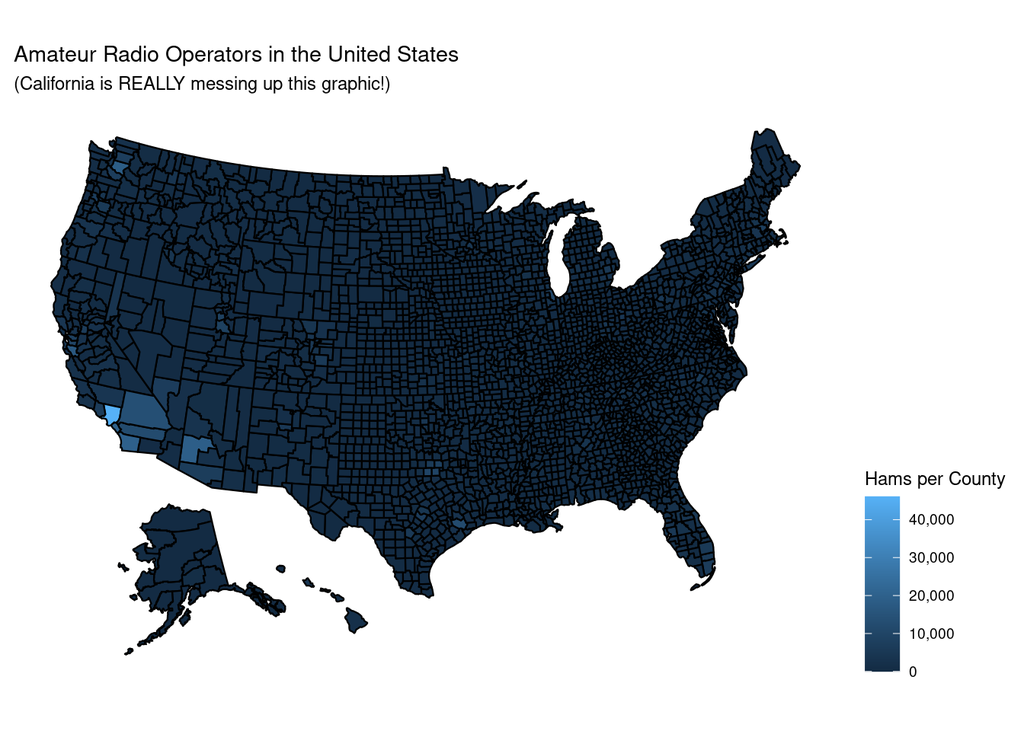

So, Southern California is loaded with hams. Let’s just take the log of this data so we can get another viewpoint, shall we? (Just for fun!)

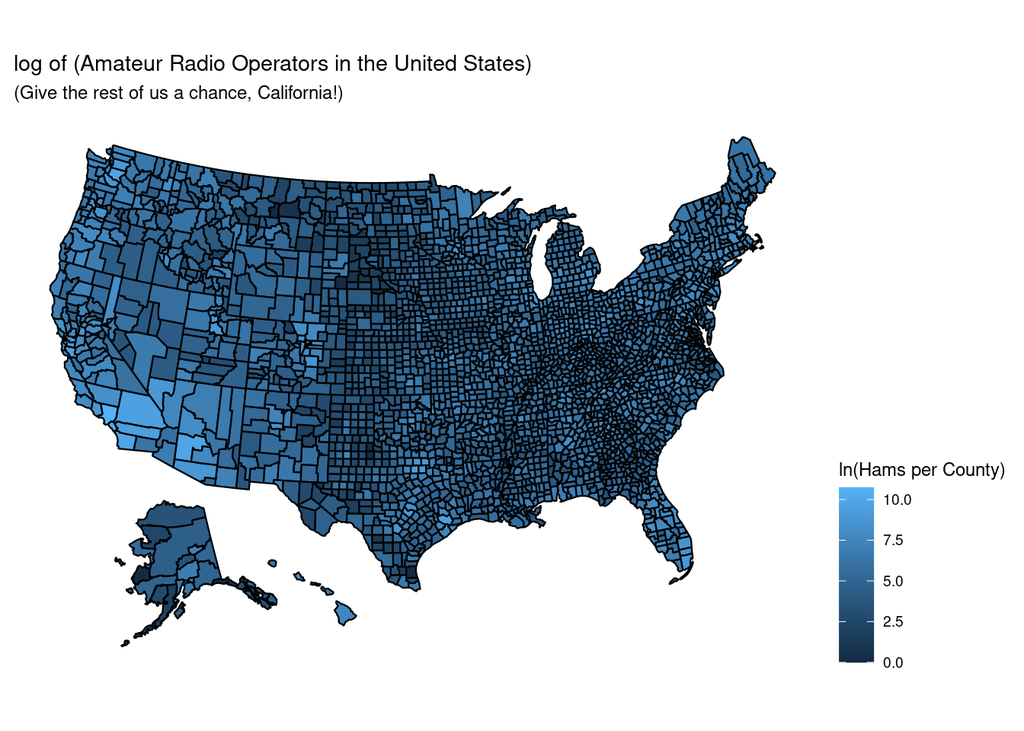

But what we really want to know is where to put a new store, right? So let’s group some of the states together and plot the locations of the current stores. I’m starting with my home region. I might just suggest that the new store should be somewhere near DC, and this would probably not be bad at all! Lots of “smart people” travel to DC on business and might be happy to take a side trip. I know there is already a store in Virginia, but it seriously would take 2 to 3 hours to get to it from Fort Meade depending on the traffic. That 95 corridor can get really horrific!

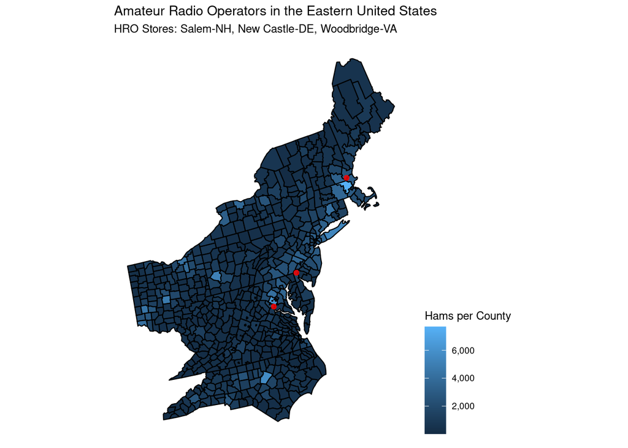

It was so much fun making that map, I thought I should group other states together to show off their stores! Here are some in the southern US.

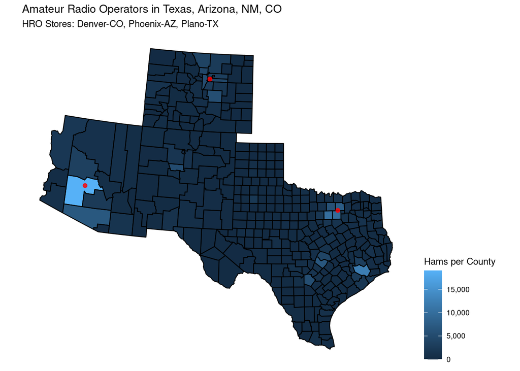

Of course, California!

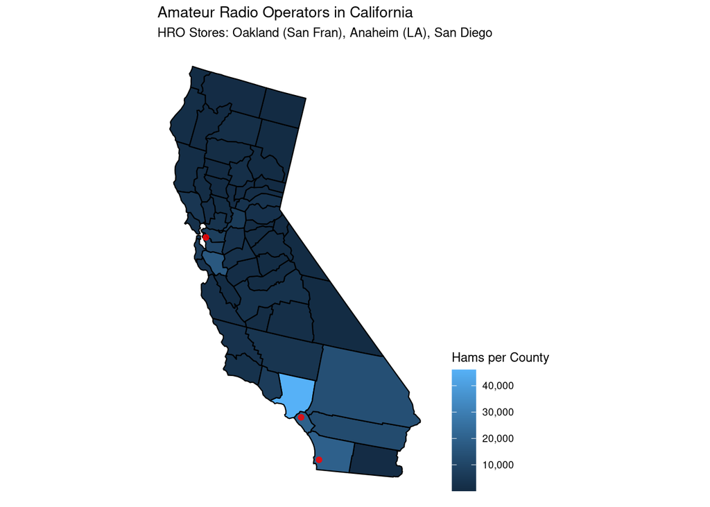

Oregon has quite a few hams!

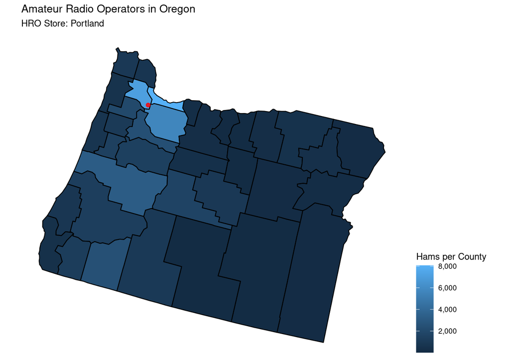

And so does Milwaukee!

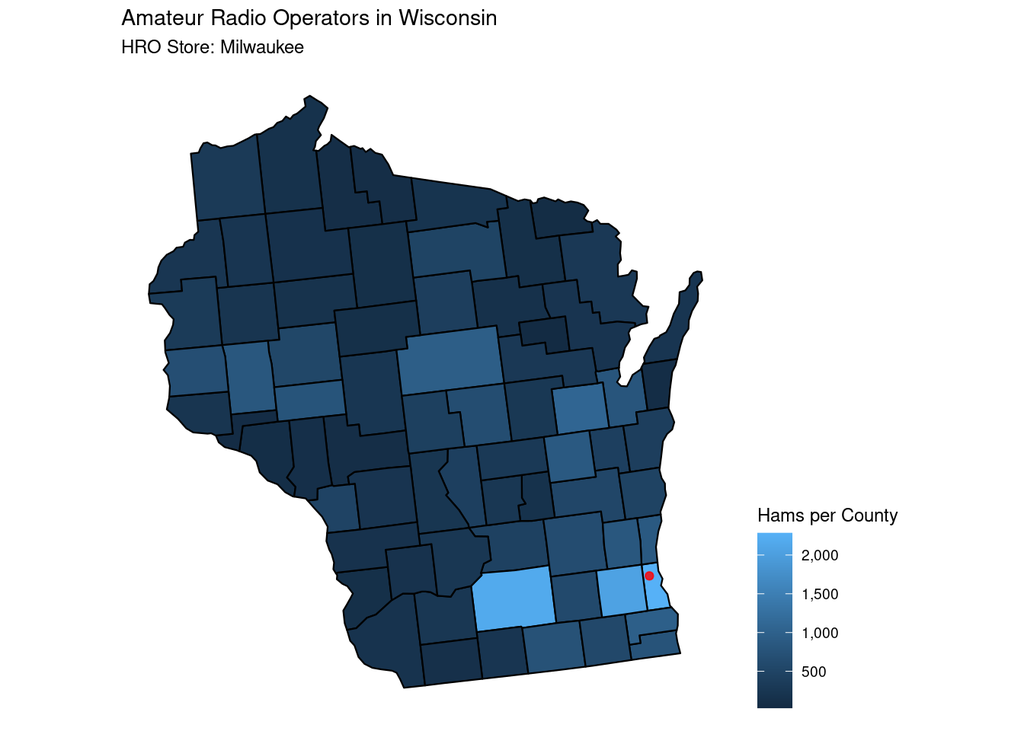

Also Atlanta.

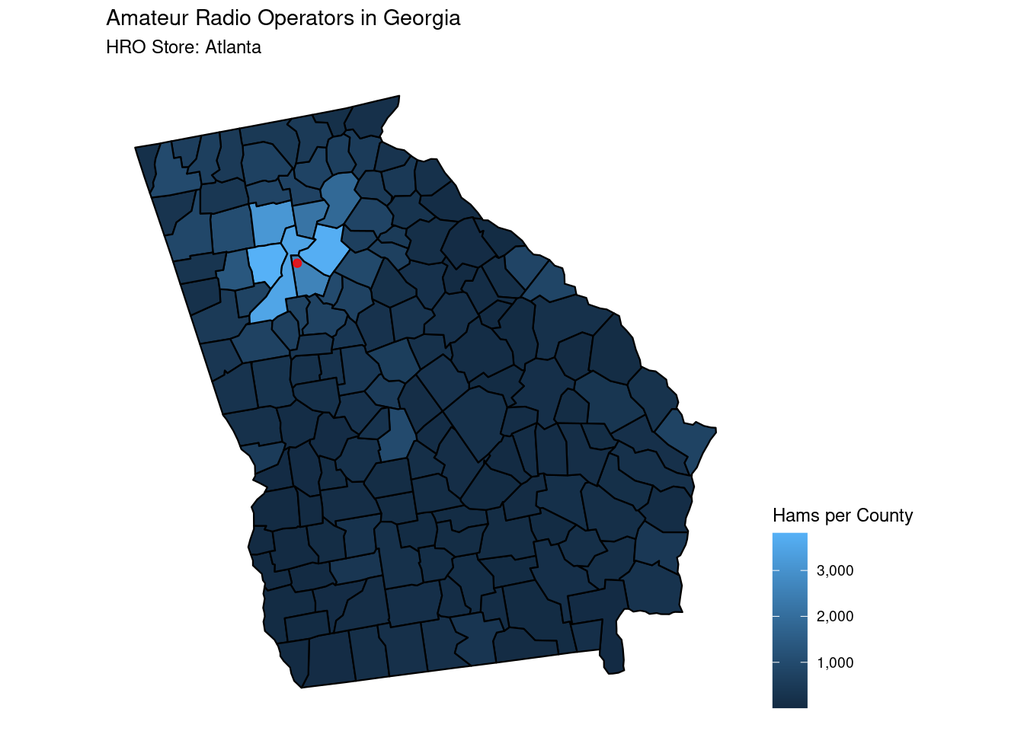

So I hope you enjoyed looking at my graphis. I had fun making them. But in reality, I think there should be a new store either in Dayton, Ohio, or at least put one near Pittsburgh in a place where it would be convenient for (many of us) to stop off on our way to or from Hamvention.